# Explore Difference in Property Damage (and per Capita)

Benedito Chou

2019-04-19

## Setup Library

Install these packages if neccessary.

```r
library(readr)
library(gamlss)
library(tidyr)
library(knitr)
library(DT)
library(dplyr)
library(stringr)
library(scales)
library(broom)
library(ggplot2)
library(ggbeeswarm)
library(MASS)
library(pscl)
library(boot)
library(nlme)
library(cplm)
```

## Data Preparation

### Load Data

Load the data imported, processed and saved from “data wrangle change score centroid and map data.R”.

```r
load("processed_data v4.RData")
```

### Prepare Data

Keep distinct records within each time point only because keeping all pairwise records will inflate the number of observations in time 1 and 2.

```r
data_long <- distinct(merged_data_record_all_long, tribe, time, FIPS, .keep_all = TRUE)
```

Create data.frame to include only tribes with time 1 and 2 data.

```r
data_t1and2_long <- filter(data_long, tribe %in% tribes_time1and2_lst$tribe)
```

Convert time and tribe to factor for statistical modeling

```r
data_long <- data_long %>%
  ungroup() %>%
  mutate(tribe = factor(tribe),
         time = factor(time))

data_t1and2_long <- data_t1and2_long %>%
  ungroup() %>%
  mutate(tribe = factor(tribe),
         time = factor(time))
```

**Check Data**

First, confirm the data is correct, each tribe should have 2 summarized records in total, one for time 1 and one for time 2, so the resulted data.frame should has 0 row.

```r
t1and2_lst <- group_by(data_t1and2_long, tribe, time) %>%
  count() %>%
  ungroup() %>%
  group_by(tribe) %>%
  count() %>%
  filter(n < 2)

nrow(t1and2_lst)
```

```
## [1] 0
```

## Exploratory Analyses

### All Tribes, including those with time 1 or time 2 data only

### Plot Property Damage by Time

- The distribution of property damage in time 1 and time 2 is skewed to the right and is zero-inflated with notable outliers.
- The distirbution of property damage is in general higher in time 2 compared to time 1.

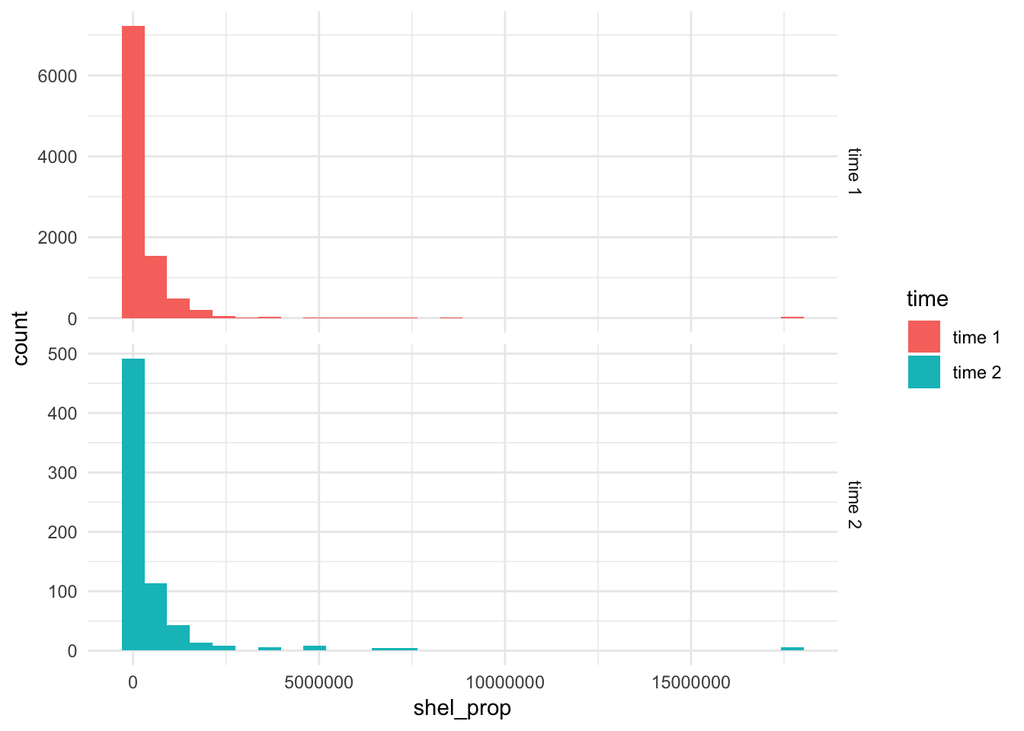

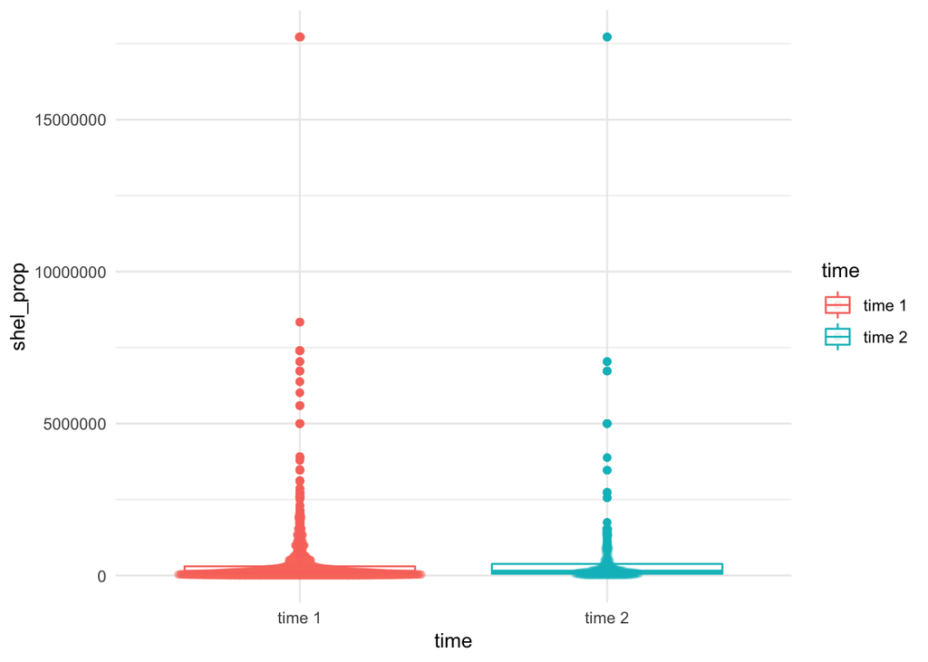

#### Look at those with property damage only and 90th percentile cutoff

- The distirbution of property damage is in general higher in time 2 compared to time 1 for tribes in counties with property damage only.

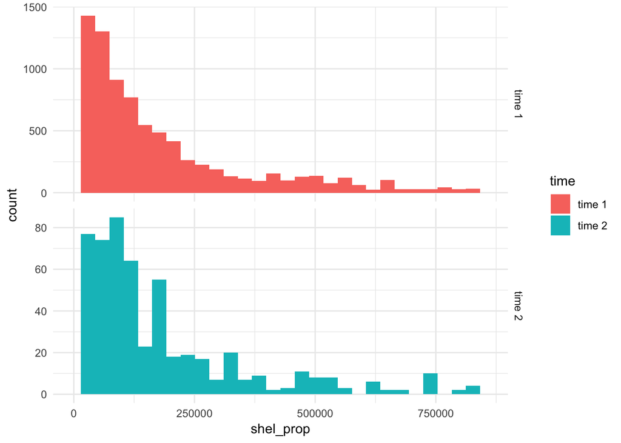

```r
data_long_shel_prop_only <- filter(data_long, shel_prop > 0)

ggplot(data_long_shel_prop_only, aes(shel_prop, fill = time)) +
  facet_grid(rows = vars(time), scales = "free") +
  geom_histogram(position = "dodge") +
  theme_minimal() +
  xlim(0, quantile(data_long_shel_prop_only$shel_prop, c(.90), na.rm = TRUE))
```

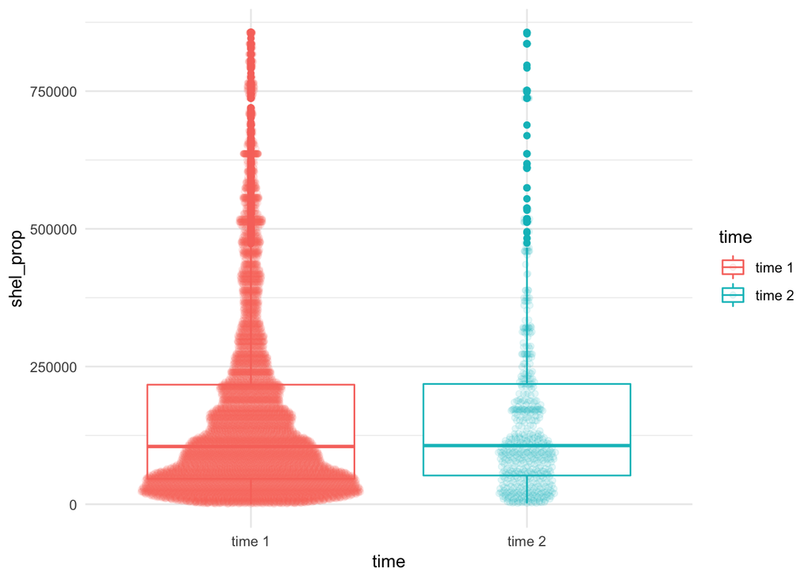

```r
ggplot(data_long_shel_prop_only, aes(time, shel_prop, colour = time)) +
  geom_boxplot() +
  geom_quasirandom(alpha = 1/10, varwidth = TRUE) +
  theme_minimal() +
  ylim(0, quantile(data_long_shel_prop_only$shel_prop, c(.90), na.rm = TRUE))
```

### Plot Property Damage per capita by Time

- The distribution of property damage per capita in time 1 and time 2 is skewed to the right and is zero-inflated with notable outliers.
- The distirbution of property damage per capita is in general higher in time 1 compared to time 2.

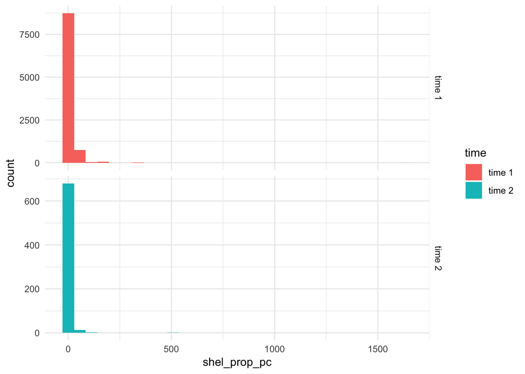

```r
ggplot(data_long, aes(shel_prop_pc, fill = time)) +
  facet_grid(rows = vars(time), scales = "free") +
  geom_histogram(position = "dodge", bin = 70) +
  theme_minimal()
```

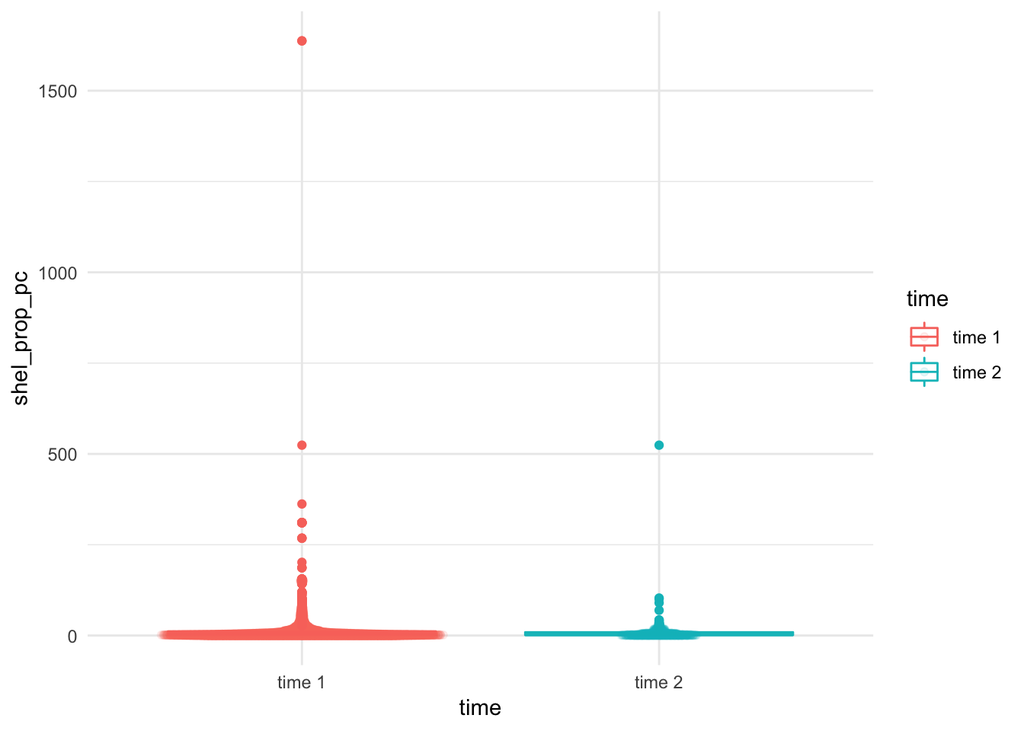

```r
ggplot(data_long, aes(time, shel_prop_pc, colour = time)) +
  geom_boxplot() +
  geom_quasirandom(alpha = 1/10, varwidth = TRUE) +
  theme_minimal()
```

#### Look at those with property damage only and 90th percentile cutoff

- The distirbution of property damage per capita is in general higher in time 2 compared to time 1 for tribes in counties with property damage only.

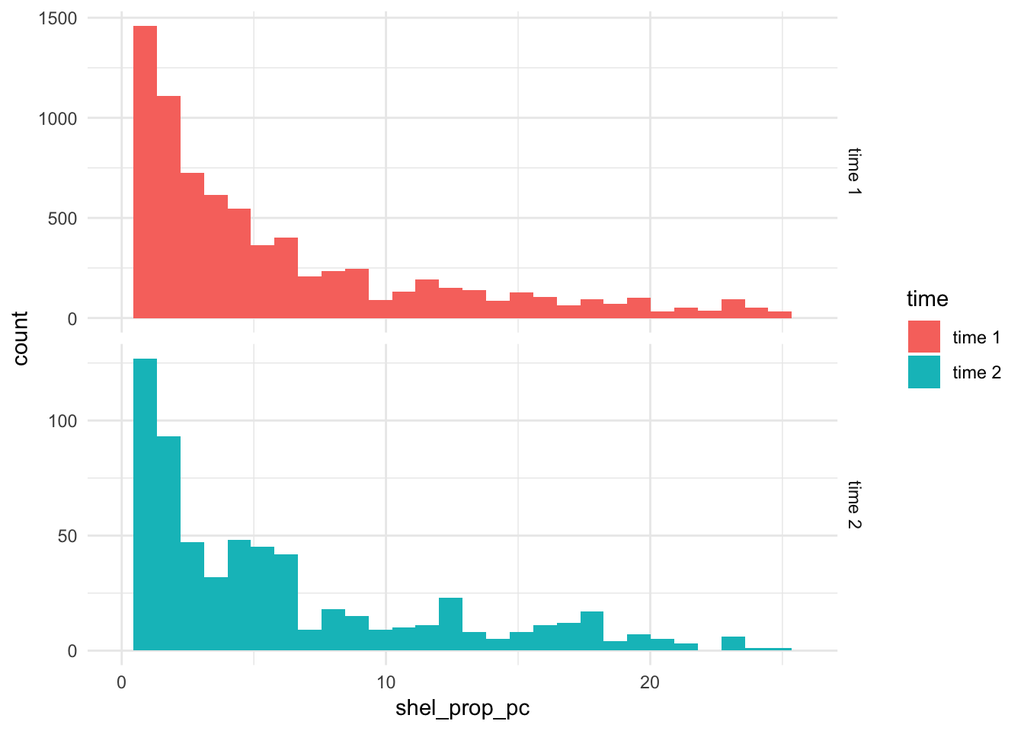

```r
data_long_shel_prop_pc_only <- filter(data_long, shel_prop_pc > 0)

ggplot(data_long_shel_prop_pc_only, aes(shel_prop_pc, fill = time)) +
  facet_grid(rows = vars(time), scales = "free") +
  geom_histogram(position = "dodge") +
  theme_minimal() +
  xlim(0, quantile(data_long_shel_prop_pc_only$shel_prop_pc, c(.90), na.rm = TRUE))
```

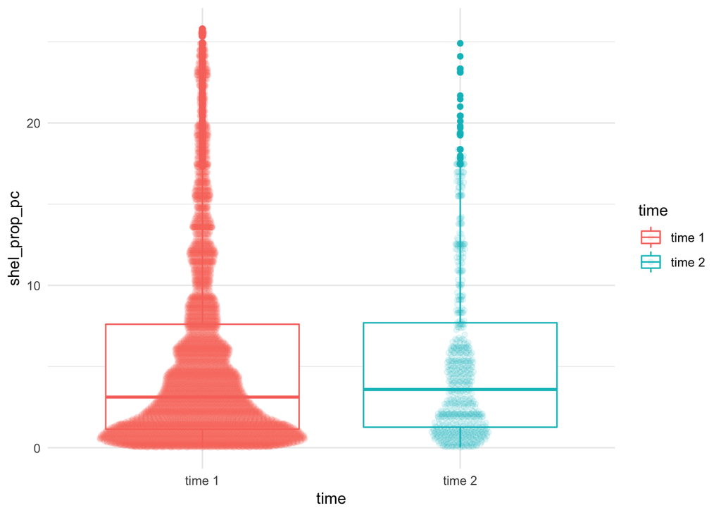

```r
ggplot(data_long_shel_prop_pc_only, aes(time, shel_prop_pc, colour = time)) +
  geom_boxplot() +
  geom_quasirandom(alpha = 1/10, varwidth = TRUE) +
  theme_minimal() +
  ylim(0, quantile(data_long_shel_prop_only$shel_prop_pc, c(.90), na.rm = TRUE))
```

### Tribes with both time 1 or time 2 data

### Plot Property Damage by Time

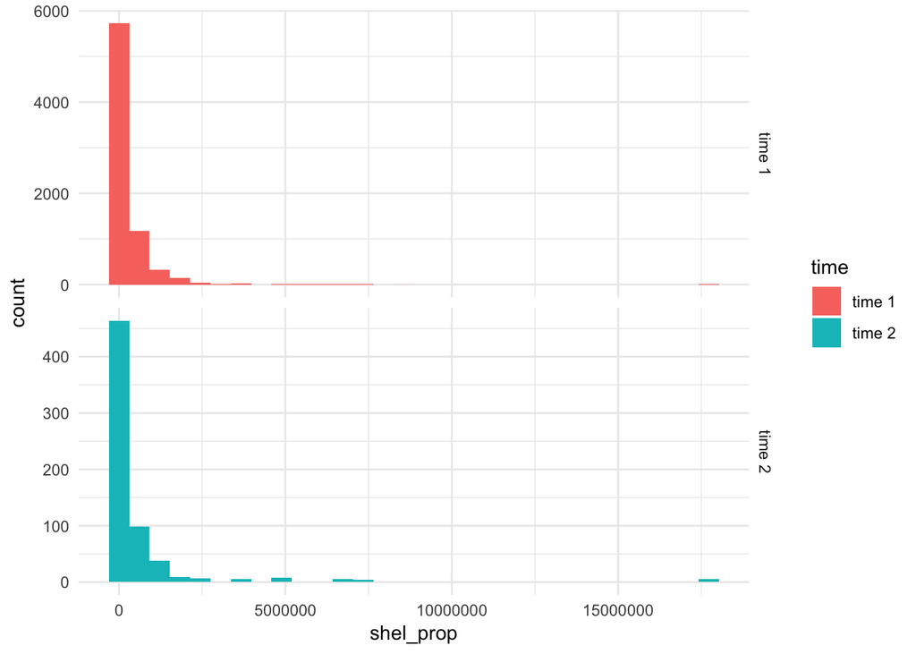

```r
ggplot(data_t1and2_long, aes(shel_prop, fill = time)) +
  facet_grid(rows = vars(time), scales = "free") +
  geom_histogram(position = "dodge", bin = 70) +
  theme_minimal()
```

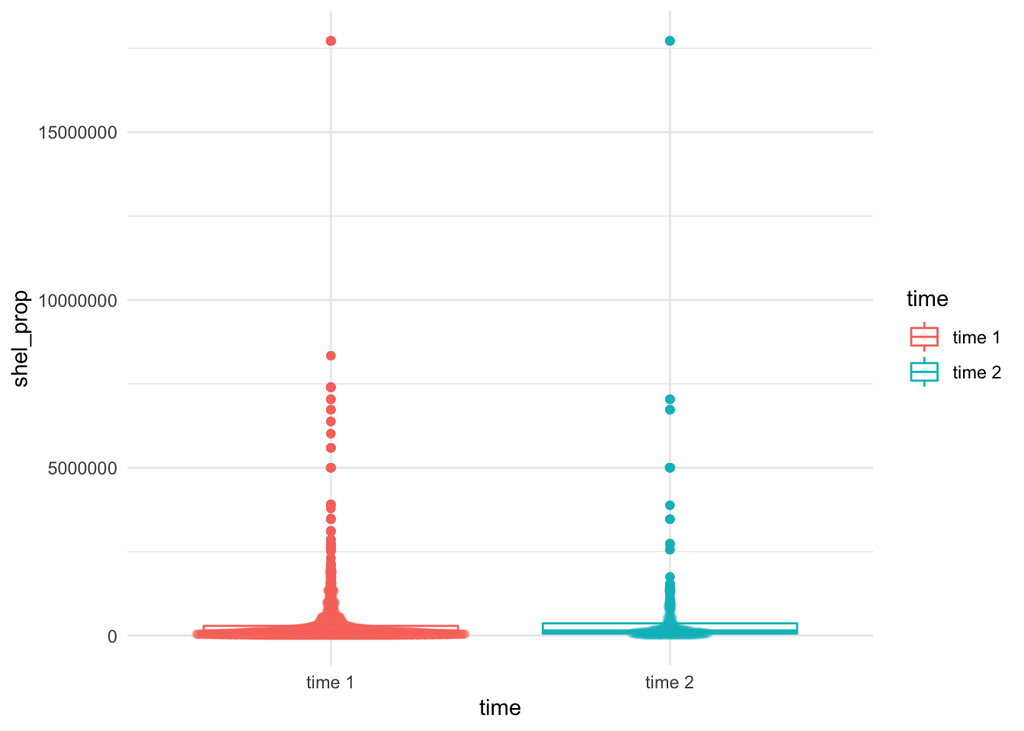

```r
ggplot(data_t1and2_long, aes(time, shel_prop, colour = time)) +
  geom_boxplot() +
  geom_quasirandom(alpha = 1/10, varwidth = TRUE) +
  theme_minimal()
```

#### Look at only those with property damage only and 90th percentile cutoff

- The distirbution of property damage is in general higher in time 1 compared to time 2 for tribes in counties with property damage only.

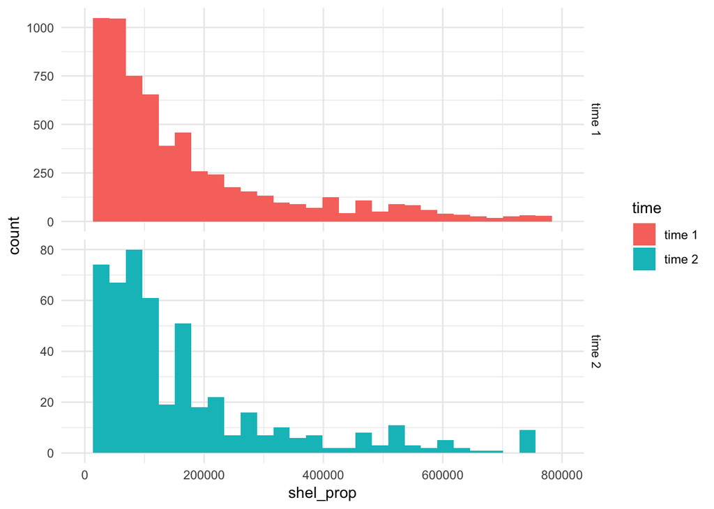

```r
data_t1and2_long_shel_prop_only <- filter(data_t1and2_long, shel_prop > 0)

ggplot(data_t1and2_long_shel_prop_only, aes(shel_prop, fill = time)) +
  facet_grid(rows = vars(time), scales = "free") +
  geom_histogram(position = "dodge") +
  theme_minimal() +
  xlim(0, quantile(data_t1and2_long_shel_prop_only$shel_prop, c(.90), na.rm = TRUE))
```

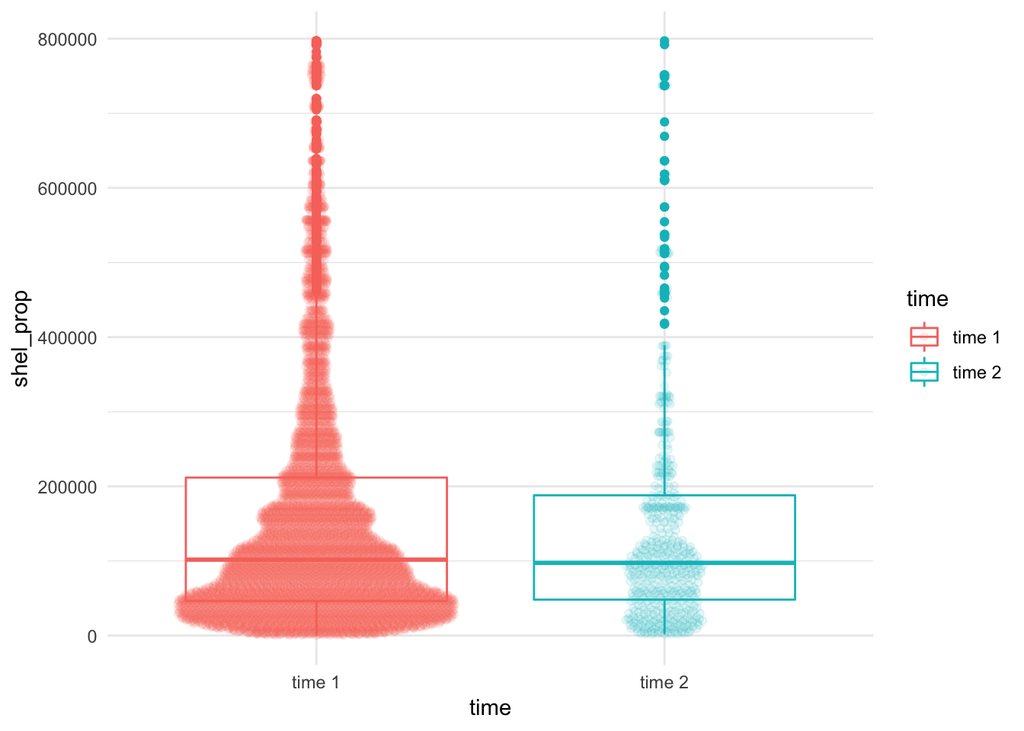

```r
ggplot(data_t1and2_long_shel_prop_only, aes(time, shel_prop, colour = time)) +
  geom_boxplot() +
  geom_quasirandom(alpha = 1/10, varwidth = TRUE) +
  theme_minimal() +
  ylim(0, quantile(data_t1and2_long_shel_prop_only$shel_prop, c(.90), na.rm = TRUE))
```

### Plot Property Damage per capita by Time

- The distribution of property damage per capita in time 1 and time 2 is skewed to the right and is zero-inflated with notable outliers.
- The distirbution of property damage per capita is in general higher in time 1 compared to time 2.

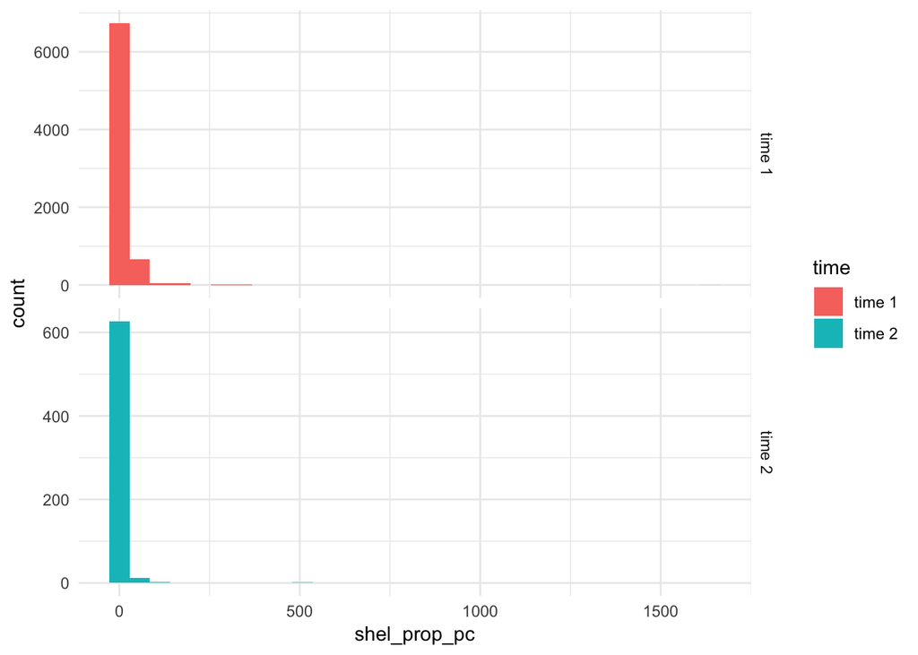

```r
ggplot(data_t1and2_long, aes(shel_prop_pc, fill = time)) +
  facet_grid(rows = vars(time), scales = "free") +
  geom_histogram(position = "dodge", bin = 70) +
  theme_minimal()
```

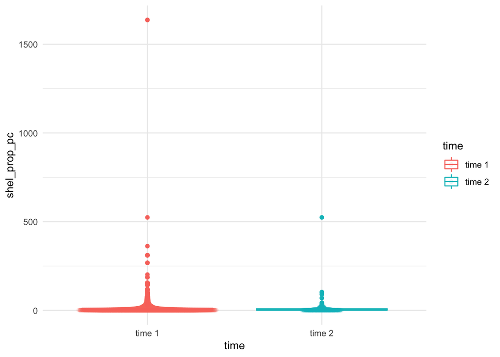

```r
ggplot(data_t1and2_long, aes(time, shel_prop_pc, colour = time)) +
  geom_boxplot() +
  geom_quasirandom(alpha = 1/10, varwidth = TRUE) +
  theme_minimal()
```

#### Look at those with property damage only and 90th percentile cutoff

- The distirbution of property damage per capita is in general higher in time 1 compared to time 2 for tribes in counties with property damage only.

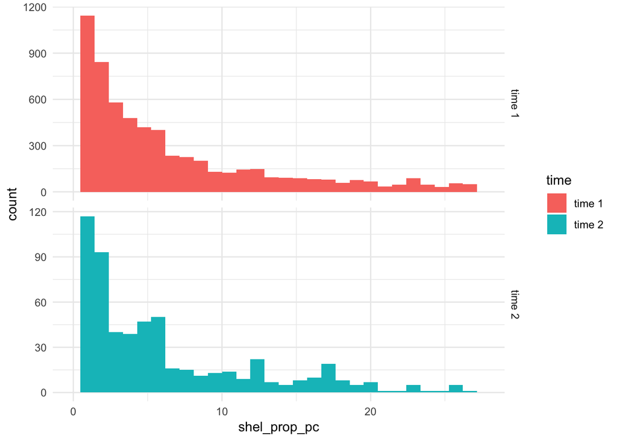

```r
data_t1and2_long_shel_prop_pc_only <- filter(data_t1and2_long, shel_prop_pc > 0)

ggplot(data_t1and2_long_shel_prop_pc_only, aes(shel_prop_pc, fill = time)) +
  facet_grid(rows = vars(time), scales = "free") +
  geom_histogram(position = "dodge") +
  theme_minimal() +
  xlim(0, quantile(data_t1and2_long_shel_prop_pc_only$shel_prop_pc, c(.90), na.rm = TRUE))
```

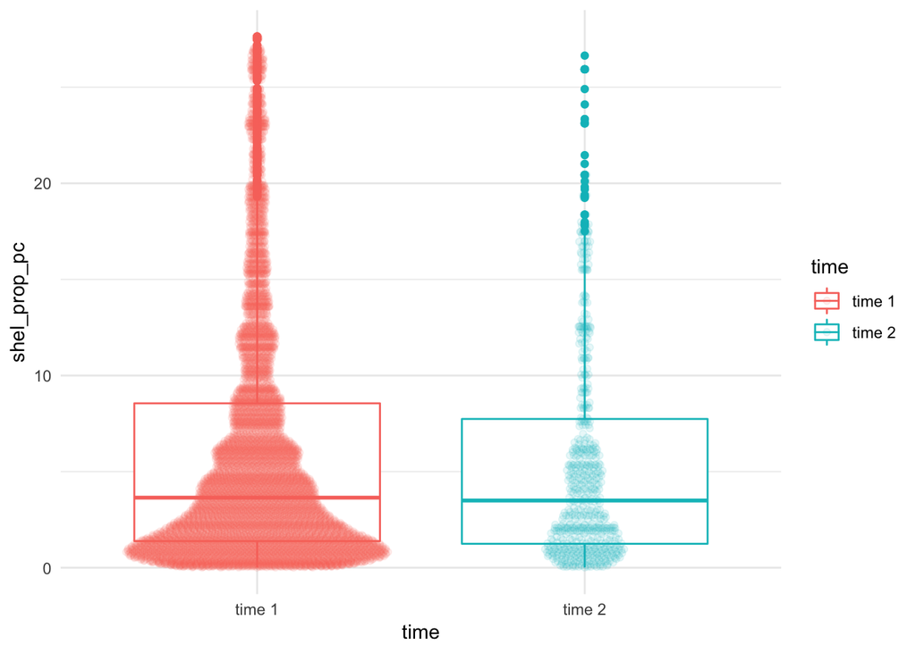

```r
ggplot(data_t1and2_long_shel_prop_pc_only, aes(time, shel_prop_pc, colour = time)) +
  geom_boxplot() +
  geom_quasirandom(alpha = 1/10, varwidth = TRUE) +
  theme_minimal() +
  ylim(0, quantile(data_t1and2_long_shel_prop_pc_only$shel_prop_pc, c(.90), na.rm = TRUE))
```

### Plot relationship between Time 1 and Time 2 Property Damage at tribe level

- Compute the mean and median values of each tribe at time 1 and time 2. Look at the median as well as the mean because the median is a robust measure of central tendency and extreme-value resistent while the mean is heavily influenced by outliers.

#### Relationship between Time 1 and Time 2 Property Damage

- We found a large positive linear relationships between time 1 and time 2 property damage for mean (r = 0.758) and median (r = 0.5784)

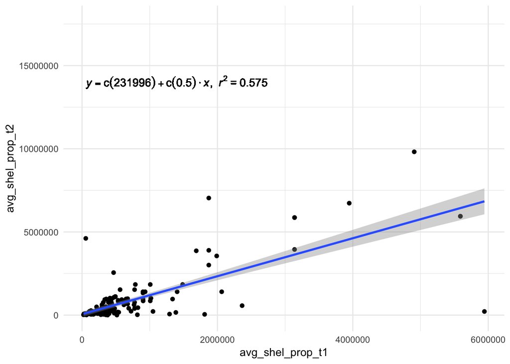

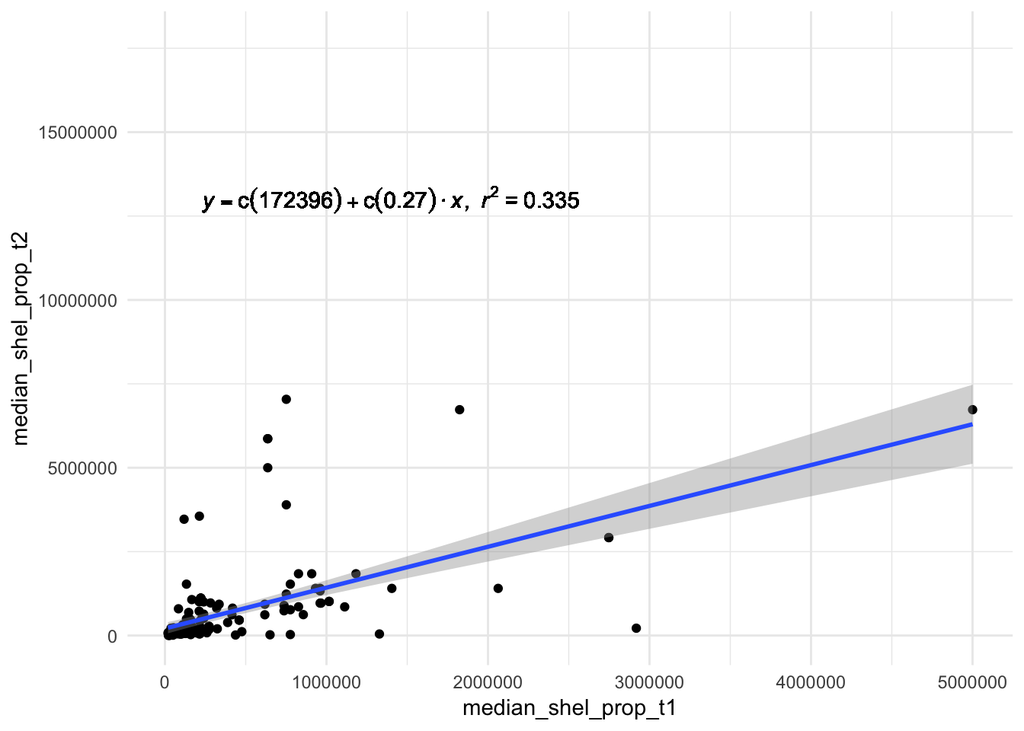

#### Relationship between Time 1 and Time 2 Property Damage per Capita

- We found a medium positive linear relationship between time 1 and time 2 property damage per capita for mean (r = 0.3758) and median (r = 0.4895)

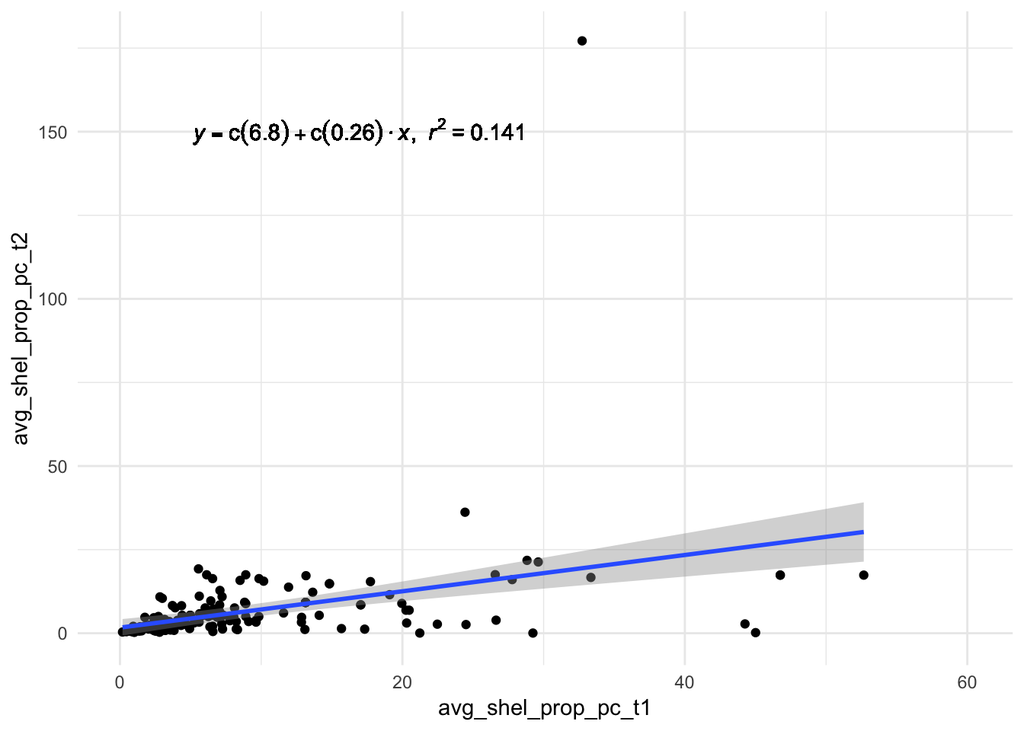

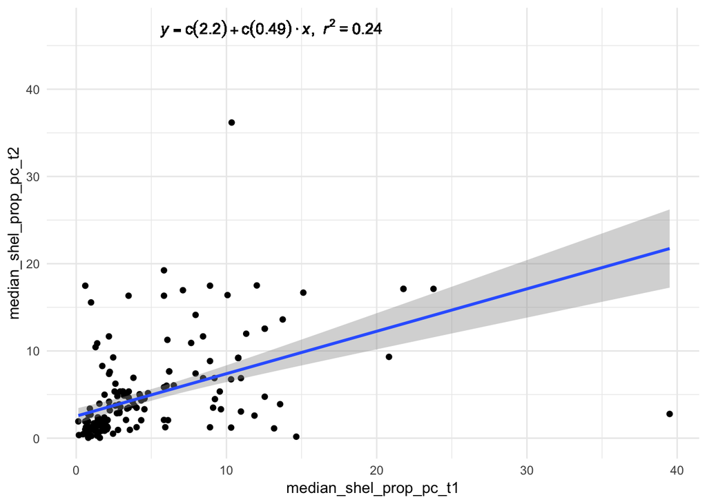

## Test for Significant Difference

### (1) Test for significant difference at the aggregate level

- We applied three statistical models - Linear Mixed Model, Repeated Measure ANOVA, and Zero-inflated Compound Poisson Generalized Linear Model - to examine statistical significant difference between Time 1 and Time 2 property damage and property damage per capita scores.
- The models, as applicable, are run using all records from all tribes and tribes with both time 1 and 2 data.
- The model interpretation is based on the Zero-inflated Compound Poisson Generalized Linear Model, as this is the test most appropraite for the outcome. The Linear Mixed Model and Repeated Measure ANOVA results are shown for reference purposes.

### Use all records

Filter out NA outcomes

```r
model_data_long <- filter(data_long, !is.na(shel_prop))
model_data_t1and2_long <- filter(data_t1and2_long, !is.na(shel_prop))
```

### Linear Mixed Model

- Linear mixed model is a parametric test for comparing data when one or more of the independent variables should be model as a random effect because of variations by that variable.

```r
# Linear Mixed Model raw
lme_model <- nlme::lme(shel_prop ~ time, data = model_data_long, random = ~1|tribe)

summary(lme_model)
```

```
## Linear mixed-effects model fit by REML
##  Data: model_data_long
##        AIC      BIC    logLik
##   316179.7 316208.7 -158085.9
##
## Random effects:
##  Formula: ~1 | tribe
##         (Intercept) Residual
## StdDev:    912089.8  1065768
##
## Fixed effects: shel_prop ~ time
##                Value Std.Error   DF   t-value p-value
## (Intercept) 599933.7  51597.00 9909 11.627298  0.0000
## timetime 2  114940.9  45649.54 9909  2.517899  0.0118
##  Correlation:
##            (Intr)
## timetime 2 -0.127
##
## Standardized Within-Group Residuals:
##         Min          Q1         Med          Q3         Max
## -5.09838065 -0.22824100 -0.11838029  0.01637598 16.28092329
##
## Number of Observations: 10308
## Number of Groups: 398
```

```r
anova(lme_model)
```

```
##             numDF denDF   F-value p-value
## (Intercept)     1  9909 145.05048  <.0001
## time            1  9909   6.33981  0.0118
```

```r
# Linear Mixed Model per capita
lme_model <- nlme::lme(shel_prop_pc ~ time, data = model_data_long, random = ~1|tribe)

summary(lme_model)
```

```
## Linear mixed-effects model fit by REML
##  Data: model_data_long
##        AIC      BIC    logLik
##   100190.1 100219.1 -50091.06
##
## Random effects:
##  Formula: ~1 | tribe
##         (Intercept) Residual
## StdDev:    7.167057 30.86451
##
## Fixed effects: shel_prop_pc ~ time
##                 Value Std.Error   DF   t-value p-value
## (Intercept)  9.003408 0.6192425 9909 14.539390  0.0000
## timetime 2  -2.828801 1.2602150 9909 -2.244697  0.0248
##  Correlation:
##            (Intr)
## timetime 2 -0.212
##
## Standardized Within-Group Residuals:
##         Min          Q1         Med          Q3         Max
## -1.15492638 -0.21723205 -0.13427596  0.02686439 52.16082365
##
## Number of Observations: 10308
## Number of Groups: 398
```

```r
anova(lme_model)
```

```
##             numDF denDF   F-value p-value
## (Intercept)     1  9909 207.07716  <.0001
## time            1  9909   5.03867  0.0248
```

### Repeated Measure ANOVA

- See Analysis below: Repeated Measure ANOVA can only be run with tribes with both time 1 and time 2 data.

### Zero-Inflated Compound Poisson Generalized Linear Model

- Zero-inflated Compound Poisson Generalized Linear Model is a parametric test for comparing continous metrics with excessive zeros. Unlike t-test or ANOVA, this test is appropriate for data that has a non-normally distribute positive scores with a large amount of zero score, such as the outcome property damage and property damage per capita. It is a two-part models. The first part evalutes whether the outcome is zero or non-zero, the second part models the positive distribution of the non-zero scores. Different predictors can be entered to predict the outcomes in these two-parts.
- Time is entered as a predictor in both the zero-inflated and positive scores part of the modeling.

```r
# Zero-Inflated Compound Poisson Generalized Linear Model! raw
zcpglm_model <- zcpglm(shel_prop ~ time || time, link = "log", data = model_data_long, optimizer = "nlminb")

zcpglm_model_summary <- summary(zcpglm_model)
```

```
##
## Call:
## zcpglm(formula = shel_prop ~ time || time, link = "log", data = model_data_long,
##     optimizer = "nlminb")
##
## Zero-inflation model coefficients:
##             Estimate Std. Error z value            Pr(>|z|)
## (Intercept)  -4.9589     0.1226 -40.449 <0.0000000000000002 ***
## timetime 2   -0.4864     0.5914  -0.822               0.411
##
## Compound Poisson model coefficients:
##             Estimate Std. Error z value            Pr(>|z|)
## (Intercept) 12.81192    0.01362  940.69 <0.0000000000000002 ***
## timetime 2   0.53445    0.05214   10.25 <0.0000000000000002 ***
## ---
## Signif. codes:  0 '***' 0.001 '**' 0.01 '*' 0.05 '.' 0.1 ' ' 1
##
## Estimated dispersion parameter: 2.0122
## Estimated index parameter: 1.99
```

```r
model_para <- coef(zcpglm_model_summary)

mean_t1 <- round(mean(filter(data_long, time == "time 1")$shel_prop, na.rm = T), 3)
mean_t2 <- round(mean(filter(data_long, time == "time 2")$shel_prop, na.rm = T), 3)
sd_t1 <- round(sd(filter(data_long, time == "time 1")$shel_prop, na.rm = T), 3)
sd_t2 <- round(sd(filter(data_long, time == "time 2")$shel_prop, na.rm = T), 3)

pvalue <- round(model_para$tweedie[2,4], 3)
zvalue <- round(model_para$tweedie[2,3], 3)
parameter <- NA
```

**Interpretation**

- At the aggregate level, the difference in property damage between time 1 (M = 364005.496, SD = 1104444.75) and time 2 (M = 622858.081, SD = 1898970.882) was statistically signficant (z = 10.25, p < .001).

```r
# Zero-Inflated Compound Poisson Generalized Linear Model! per capita
zcpglm_model <- zcpglm(shel_prop_pc ~ time || time, link = "log", data = model_data_long, optimizer = "nlminb")

zcpglm_model_summary <- summary(zcpglm_model)
```

```
##
## Call:
## zcpglm(formula = shel_prop_pc ~ time || time, link = "log", data = model_data_long,
##     optimizer = "nlminb")
##
## Zero-inflation model coefficients:
##             Estimate Std. Error z value            Pr(>|z|)
## (Intercept)  -4.9589     0.1226 -40.448 <0.0000000000000002 ***
## timetime 2   -0.4864     0.5914  -0.822               0.411
##
## Compound Poisson model coefficients:
##             Estimate Std. Error z value             Pr(>|z|)
## (Intercept)  2.41571    0.01363 177.290 < 0.0000000000000002 ***
## timetime 2  -0.36729    0.05239  -7.011     0.00000000000236 ***
## ---
## Signif. codes:  0 '***' 0.001 '**' 0.01 '*' 0.05 '.' 0.1 ' ' 1
##
## Estimated dispersion parameter: 1.8151
## Estimated index parameter: 1.99
```

```r
model_para <- coef(zcpglm_model_summary)

mean_t1 <- round(mean(filter(data_long, time == "time 1")$shel_prop, na.rm = T), 3)
mean_t2 <- round(mean(filter(data_long, time == "time 2")$shel_prop, na.rm = T), 3)
sd_t1 <- round(sd(filter(data_long, time == "time 1")$shel_prop, na.rm = T), 3)
sd_t2 <- round(sd(filter(data_long, time == "time 2")$shel_prop, na.rm = T), 3)

pvalue <- round(model_para$tweedie[2,4], 3)
zvalue <- round(model_para$tweedie[2,3], 3)
parameter <- NA
```

**Interpretation**

### Use only records where tribes have time 1 and 2 data

### Linear Mixed Model

```r
# Linear Mixed Model raw
lme_model <- nlme::lme(shel_prop ~ time, data = model_data_t1and2_long, random = ~1|tribe)

summary(lme_model)
```

```
## Linear mixed-effects model fit by REML
##  Data: model_data_t1and2_long
##        AIC      BIC    logLik
##   248589.2 248617.2 -124290.6
##
## Random effects:
##  Formula: ~1 | tribe
##         (Intercept) Residual
## StdDev:    944339.5 969847.8
##
## Fixed effects: shel_prop ~ time
##                Value Std.Error   DF  t-value p-value
## (Intercept) 612040.6  74006.25 7974 8.270121  0.0000
## timetime 2   98264.2  42323.13 7974 2.321760  0.0203
##  Correlation:
##            (Intr)
## timetime 2 -0.114
##
## Standardized Within-Group Residuals:
##         Min          Q1         Med          Q3         Max
## -5.74869147 -0.24309421 -0.12335718  0.01613097 17.88635190
##
## Number of Observations: 8159
## Number of Groups: 184
```

```r
anova(lme_model)
```

```
##             numDF denDF  F-value p-value
## (Intercept)     1  7974 73.78410  <.0001
## time            1  7974  5.39057  0.0203
```

```r
# Linear Mixed Model per capita
lme_model <- nlme::lme(shel_prop_pc ~ time, data = model_data_t1and2_long, random = ~1|tribe)

summary(lme_model)
```

```
## Linear mixed-effects model fit by REML
##  Data: model_data_t1and2_long
##        AIC      BIC    logLik
##   80730.04 80758.06 -40361.02
##
## Random effects:
##  Formula: ~1 | tribe
##         (Intercept) Residual
## StdDev:    8.115547 33.72087
##
## Fixed effects: shel_prop_pc ~ time
##                 Value Std.Error   DF   t-value p-value
## (Intercept) 10.417230 0.8775412 7974 11.870929  0.0000
## timetime 2  -3.522329 1.4366003 7974 -2.451851  0.0142
##  Correlation:
##            (Intr)
## timetime 2 -0.229
##
## Standardized Within-Group Residuals:
##         Min          Q1         Med          Q3         Max
## -1.07668239 -0.21120524 -0.12857536  0.02978946 47.73602612
##
## Number of Observations: 8159
## Number of Groups: 184
```

```r
anova(lme_model)
```

```
##             numDF denDF   F-value p-value
## (Intercept)     1  7974 134.98389  <.0001
## time            1  7974   6.01157  0.0142
```

### Repeated Measure ANOVA

- Repeated Measure ANOVA can only be run with tribes with both time 1 and time 2 data.

```r
# Repeated Measure ANOVA raw
aov_model <- aov(shel_prop ~ time + Error(tribe / time), data = model_data_t1and2_long)

summary(aov_model)
```

```
##
## Error: tribe
##            Df           Sum Sq         Mean Sq F value    Pr(>F)
## time        1  166307874736794 166307874736794   16.77 0.0000634 ***
## Residuals 182 1805006316466426   9917617123442
## ---
## Signif. codes:  0 '***' 0.001 '**' 0.01 '*' 0.05 '.' 0.1 ' ' 1
##
## Error: tribe:time
##            Df          Sum Sq       Mean Sq F value Pr(>F)
## time        1   4051926647494 4051926647494    2.81 0.0954 .
## Residuals 183 263905299460259 1442105461531
## ---
## Signif. codes:  0 '***' 0.001 '**' 0.01 '*' 0.05 '.' 0.1 ' ' 1
##
## Error: Within
##             Df           Sum Sq      Mean Sq F value Pr(>F)
## Residuals 7791 7234433946593285 928562950403
```

```r
# Repeated Measure ANOVA per capita
aov_model <- aov(shel_prop_pc ~ time + Error(tribe / time), data = model_data_t1and2_long)

summary(aov_model)
```

```
##
## Error: tribe
##            Df Sum Sq Mean Sq F value Pr(>F)
## time        1  23303   23303   5.855 0.0165 *
## Residuals 182 724397    3980
## ---
## Signif. codes:  0 '***' 0.001 '**' 0.01 '*' 0.05 '.' 0.1 ' ' 1
##
## Error: tribe:time
##            Df Sum Sq Mean Sq F value  Pr(>F)
## time        1   3877    3877   8.063 0.00503 **
## Residuals 183  87996     481
## ---
## Signif. codes:  0 '***' 0.001 '**' 0.01 '*' 0.05 '.' 0.1 ' ' 1
##
## Error: Within
##             Df  Sum Sq Mean Sq F value Pr(>F)
## Residuals 7791 9040427    1160
```

### Zero-Inflated Compound Poisson Generalized Linear Model

- Zero-inflated Compound Poisson Generalized Linear Model is a parametric test for comparing continous metrics with excessive zeros. Unlike t-test or ANOVA, this test is appropriate for data that has a non-normally distribute positive scores with a large amount of zero score, such as the outcome property damage and property damage per capita. It is a two-part models. The first part evalutes whether the outcome is zero or non-zero, the second part models the positive distribution of the non-zero scores. Different predictors can be entered to predict the outcomes in these two-parts.
- Time is entered as a predictor in both the zero-inflated and positive scores part of the modeling.

```r
# Zero-Inflated Compound Poisson Generalized Linear Model! raw
zcpglm_model <- zcpglm(shel_prop ~ time || time, link = "log", data = model_data_t1and2_long, optimizer = "nlminb")

zcpglm_model_summary <- summary(zcpglm_model)
```

```
##
## Call:
## zcpglm(formula = shel_prop ~ time || time, link = "log", data = model_data_t1and2_long,
##     optimizer = "nlminb")
##
## Zero-inflation model coefficients:
##             Estimate Std. Error z value            Pr(>|z|)
## (Intercept)  -5.4238     0.1745 -31.089 <0.0000000000000002 ***
## timetime 2   -0.3477     0.7294  -0.477               0.634
##
## Compound Poisson model coefficients:
##             Estimate Std. Error z value            Pr(>|z|)
## (Intercept) 12.74963    0.01517  840.28 <0.0000000000000002 ***
## timetime 2   0.56851    0.05383   10.56 <0.0000000000000002 ***
## ---
## Signif. codes:  0 '***' 0.001 '**' 0.01 '*' 0.05 '.' 0.1 ' ' 1
##
## Estimated dispersion parameter: 1.9567
## Estimated index parameter: 1.99
```

```r
model_para <- coef(zcpglm_model_summary)

mean_t1 <- round(mean(filter(data_t1and2_long, time == "time 1")$shel_prop, na.rm = T), 3)
mean_t2 <- round(mean(filter(data_t1and2_long, time == "time 2")$shel_prop, na.rm = T), 3)
sd_t1 <- round(sd(filter(data_t1and2_long, time == "time 1")$shel_prop, na.rm = T), 3)
sd_t2 <- round(sd(filter(data_t1and2_long, time == "time 2")$shel_prop, na.rm = T), 3)

pvalue <- round(model_para$tweedie[2,4], 3)
zvalue <- round(model_para$tweedie[2,3], 3)
parameter <- NA
```

**Interpretation**

- At the aggregate level for tribes with migration, the difference in property damage area between time 1 (M = 342913.84, SD = 980768.632) and time 2 (M = 606245.124, SD = 1851737.472) was statistically signficant (z = 10.561, p < .001).

```r
# Zero-Inflated Compound Poisson Generalized Linear Model! per capita
zcpglm_model <- zcpglm(shel_prop_pc ~ time || time, link = "log", data = model_data_t1and2_long, optimizer = "nlminb")

zcpglm_model_summary <- summary(zcpglm_model)
```

```
##
## Call:
## zcpglm(formula = shel_prop_pc ~ time || time, link = "log", data = model_data_t1and2_long,
##     optimizer = "nlminb")
##
## Zero-inflation model coefficients:
##             Estimate Std. Error z value            Pr(>|z|)
## (Intercept)  -5.4237     0.1745 -31.089 <0.0000000000000002 ***
## timetime 2   -0.3479     0.7294  -0.477               0.633
##
## Compound Poisson model coefficients:
##             Estimate Std. Error z value            Pr(>|z|)
## (Intercept)  2.51213    0.01506 166.792 <0.0000000000000002 ***
## timetime 2  -0.47010    0.05369  -8.755 <0.0000000000000002 ***
## ---
## Signif. codes:  0 '***' 0.001 '**' 0.01 '*' 0.05 '.' 0.1 ' ' 1
##
## Estimated dispersion parameter: 1.7404
## Estimated index parameter: 1.99
```

```r
model_para <- coef(zcpglm_model_summary)

mean_t1 <- round(mean(filter(data_t1and2_long, time == "time 1")$shel_prop, na.rm = T), 3)
mean_t2 <- round(mean(filter(data_t1and2_long, time == "time 2")$shel_prop, na.rm = T), 3)
sd_t1 <- round(sd(filter(data_t1and2_long, time == "time 1")$shel_prop, na.rm = T), 3)
sd_t2 <- round(sd(filter(data_t1and2_long, time == "time 2")$shel_prop, na.rm = T), 3)

pvalue <- round(model_para$tweedie[2,4], 3)
zvalue <- round(model_para$tweedie[2,3], 3)
parameter <- NA
```

**Interpretation**

### (2) Test for significant difference at tribe level

- At the tribe level, only the Zero-Inflated Compound Poisson Generalized Linear Model is run.

```r
tribe_with_dif <- filter(merged_data_tribe, avg_shel_prop_change_score > 0) %>% group_by(tribe) %>% count()

no_test <- nrow(tribe_with_dif)
```

### Run Zero-Inflated Compound Poisson Generalized Linear Model in Batch

- Run Zero-Inflated Compound Poisson Generalized Linear Model in batch using group_by and do at the tribe level.
- Include a try call to catch error.
- Format the results into a data.frame.
- Replace NA estimate with all NA for that comparison.

```r
model <- group_by(model_data_t1and2_long, tribe) %>%
do(tryCatch(
  {as.data.frame((coef(summary(zcpglm(shel_prop ~ time || time, link = "log", data = ., optimizer = "nlminb"))))$tweedie)},
  error = function(e) {data.frame(Estimate = NA)}
)) # keep only tweedie time component

model <- group_by(model, tribe) %>%
  filter(row_number() %% 2 == 0) %>%
  rename(p.value = `Pr(>|z|)`)
```

```r
model_pc <- group_by(model_data_t1and2_long, tribe) %>%
do(tryCatch(
  {as.data.frame((coef(summary(zcpglm(shel_prop_pc ~ time || time, link = "log", data = ., optimizer = "nlminb"))))$tweedie)},
  error = function(e) {data.frame(Estimate = NA)}
)) # keep only tweedie time component

model_pc <- group_by(model_pc, tribe) %>%
  filter(row_number() %% 2 == 0) %>%
  rename(p.value = `Pr(>|z|)`)
```

Calculate number of test based only on tribes where there is non-zero difference and sufficient data point in property damage between time 1 and 2.

```r
no_test <- nrow(filter(model, !is.na(p.value)))
```

```r
model <- model %>%
  mutate(sig = ifelse(p.value < .05 / no_test, "yes", "no"))

model_pc <- model_pc %>%
  mutate(sig = ifelse(p.value < .05 / no_test, "yes", "no"))
```

- Add damage properties, damage properties per capita, distance, and no of unique FIPS to help with interpretation
- Rename some variables for prettier column headers

```r
results_df <- inner_join(model, merged_data_tribe, by = "tribe") %>%
  mutate(`Avg Diff Damage Property` = avg_shel_prop_t2 - avg_shel_prop_t1,
         `Avg Diff Damage Property per Capita` = avg_shel_prop_pc_t2 - avg_shel_prop_pc_t1) %>%
  dplyr::select(tribe, sig, p.value, `Avg Diff Damage Property`, avg_shel_prop_t1, avg_shel_prop_t2, `Avg Diff Damage Property per Capita`, avg_shel_prop_pc_t1, avg_shel_prop_pc_t2, n_unique_FIPS_t1, n_unique_FIPS_t2, mid_dist) %>%
  arrange(p.value) %>%
  rename(
    `Avg Damage Property T1` = avg_shel_prop_t1,
    `Avg Damage Property T2` = avg_shel_prop_t2,
    `Avg Damage Property per Capita T1` = avg_shel_prop_pc_t1,
    `Avg Damage Property per Capita T2` = avg_shel_prop_pc_t2,
    `Unique FIPS T1` = n_unique_FIPS_t1,
    `Unique FIPS T2` = n_unique_FIPS_t2,
    `Mid Distance` = mid_dist)
model_pc_tojoin <- select(model_pc, tribe, sig, p.value) %>%
  rename(`sig (per capita)` = sig,
         `p.value (per capita)` = p.value)

results_df <- inner_join(results_df, model_pc_tojoin, by = "tribe") %>%
  select(tribe, sig, p.value, `sig (per capita)`, `p.value (per capita)`, everything())
```

### Results Table

#### Ordered by p value in ascending order

```r
datatable(results_df,
          filter = "top",
          options = list(pageLength = 20)) %>%
   formatRound(columns = c('p.value', 'p.value (per capita)'), digits = 3) %>%
   formatRound(columns = c('Avg Diff Damage Property', 'Avg Damage Property T1', 'Avg Damage Property T2', 'Avg Diff Damage Property per Capita', 'Avg Damage Property per Capita T1', 'Avg Damage Property per Capita T2', 'Mid Distance'), digits = 5)
```

|  | tribe | sig | p.value | sig (per capita) | p.value (per capita) | Avg Diff Damage Property | Avg Damage Property T1 | Avg Damage Property T2 | Avg Diff Damage Property per Capita | Avg Damage Property per Capita T1 | Avg Damage Property per Capita T2 | Unique FIPS T1 | Unique FIPS T2 | Mid Distance |
| --- | --- | --- | --- | --- | --- | --- | --- | --- | --- | --- | --- | --- | --- | --- |
| 1 | Pamunkey | yes | 3.33167572100639e-18 | no | 0.309130366982294 | -336656.549 | 352200.414 | 15543.865 | -1.539204 | 2.549389 | 1.010185 | 5 | 1 | 108.322785282944 |
| 2 | Chippewa | yes | 7.82558026595472e-11 | no | 0.0237965863660725 | -224760.112927466 | 304785.884268929 | 80025.7713414634 | -2.93749805100936 | 7.84027244125326 | 4.9027743902439 | 383 | 41 | 535.353093075632 |
| 3 | Mohican | yes | 1.34436349970224e-05 | no | 0.00030580147117379 | -1764822.64117647 | 1810910.79617647 | 46088.155 | -11.9711632352941 | 13.0948532352941 | 1.12369 | 17 | 1 | 576.410872634326 |
| 4 | Hopi | yes | 8.5538420946161e-05 | no | 0.254401428853279 | 4558169.754 | 55104.915 | 4613274.669 | 2.996636 | 1.763325 | 4.759961 | 3 | 5 | 295.822625208433 |
| 5 | Washoe | no | 0.000646766861717867 | no | 0.485877751657966 | -1229259.42837097 | 1292418.27887097 | 63158.8505 | -0.448841983870968 | 6.02269048387097 | 5.5738485 | 21 | 7 | 95.9421542749148 |
| 6 | Omaha | no | 0.00237010645750409 | no | 0.0190828480626245 | -251063.401176471 | 277994.211176471 | 26930.81 | -17.2474125 | 20.30163 | 3.0542175 | 85 | 2 | 110.746947431243 |
| 7 | Blackfeet | no | 0.00281101628434823 | no | 0.00118033793225597 | -55587.1328571429 | 66108.7328571429 | 10521.6 | -16.11456375 | 17.32889875 | 1.214335 | 28 | 2 | 267.403013764987 |
| 8 | Yahooskin | no | 0.0107959699196758 | no | 0.00234002733849309 | -511975.839615385 | 515036.369615385 | 3060.53 | -29.1920023076923 | 29.2404623076923 | 0.04846 | 10 | 1 | 40.7901412605715 |
| 9 | Chickasaw | no | 0.0138963659243894 | no | 0.467214433689739 | -100060.859715447 | 167480.734715447 | 67419.875 | -1.25830935772358 | 6.25320735772358 | 4.994898 | 114 | 5 | 605.813624572436 |
| 10 | Klamath | no | 0.0139259559443899 | no | 0.00437573733080804 | -374384.459722222 | 377444.989722222 | 3060.53 | -21.1828905555556 | 21.2313505555556 | 0.04846 | 13 | 1 | 62.3142754216273 |

[output cut: 157 more lines]

```r
b_sig_tribe_lst <- filter(results_df, sig == "yes") %>%
  dplyr::select(tribe)
sig_tribe_lst <- filter(results_df, p.value < .05) %>%
  dplyr::select(tribe)

b_pc_sig_tribe_lst <- filter(results_df, `sig (per capita)` == "yes") %>%
  dplyr::select(tribe)
pc_sig_tribe_lst <- filter(results_df, `p.value (per capita)` < .05) %>%
  dplyr::select(tribe)
```

**Interpretation**

- The mean property damage comparisons for 4 tribes (Pamunkey, Chippewa, Mohican, Hopi) achieve statistical significance when the Bonferroni correction is used.
- The mean property damage per capita comparisons for 1 tribes (Pawnee) achieve statistical significance when the Bonferroni correction is used.
- The tests have low statistical power to detect differences given the number of observations at time 2 is much smaller than time 1.
- If Bonferroni correction is not used, property damage was significantly differ between time 1 and 2 for 19 tribes :(Pamunkey, Chippewa, Mohican, Hopi, Washoe, Omaha, Blackfeet, Yahooskin, Chickasaw, Klamath, Colorado River, Hupa, Me-Wuk, Absentee-Shawnee, Samish, Puyallup, Quechan, Nez Perce, Sioux).
- If Bonferroni correction is not used, property damage per capita was significantly differ between time 1 and 2 for 24 tribes :(Chippewa, Mohican, Omaha, Blackfeet, Yahooskin, Klamath, Hupa, Samish, Puyallup, Quechan, Pawnee, Duwamish, Catawba, Hidatsa, Mandan, Caddo, S’Klallam, Cowlitz, Apache, Miccosukee, Arikara, Nipmuc, Comanche, Kiowa).
- Results with NA p values are from tribes where there isn’t sufficient data points in both time point to perform the planned statistical tests.

**Overall Interpretation**

- Overall, statistically significant difference were found at the aggregate level when data for all tribes and tribes with migrations were analyzed on the outcome property damage scores and property damage per capita.
- At the tribe level, when correction for multiple comparisons was made, property damage for 4 tribes were found to be statistically differ between time 1 and time 2.
- At the tribe level, when correction for multiple comparisons was made, property damage per capita for 1 tribes were found to be statistically differ between time 1 and time 2.
- The lack of significant differences at the tribe level could be attributed to the low statistical power arises from the small number of observations at time 2. In some cases, there is only 1 data point in time 2 or time 1.